# Bulk 2 - apical out placental organoids

Author

Giada Guntri / HRH

Published

2026-08-14

# *Description*

*This script will generate the following plots and tables:*

*- Fig 3 e, f, g, j*

*- Supp Fig 3 a, b, c, e*

*- Supp Table 3*

# *0) Preparations*

## *load libraries*

```r
library(ggplot2)
library(PCAtools)
library(edgeR)
library(ComplexHeatmap)
library(sva)
library(ggrepel)
library(dplyr)
library(clusterProfiler)
library(org.Hs.eg.db)
library(tidyr)
library(Mfuzz)
```

## *new folders*

```r
plot_dir <- "Paper_Figures2"
if (!file.exists(plot_dir)) {
    dir.create(plot_dir, showWarnings = FALSE, recursive = FALSE)
}

table_dir <- "Paper_Tables2"
if (!file.exists(table_dir)) {
    dir.create(table_dir, showWarnings = FALSE, recursive = FALSE)
}
```

## *loading all the data*

```r
all_counts_orig <- read.delim("3797Fand3683F_raw_counts.uniqueID.20260730.tab", check.names=FALSE, stringsAsFactors=FALSE)

#Define symbol name of some genes of interest so they can be visualized in the volcano plots

all_counts_orig$SYMBOL[all_counts_orig$ENSEMBL == "ENSG00000171084"] <- "FAM86JP"

all_counts_orig$SYMBOL[all_counts_orig$ENSEMBL == "ENSG00000135248"] <- "FAM71F1"
```

## *set up metadata*

```r
# Get only the sample columns

sample_cols <- colnames(all_counts_orig)[6:ncol(all_counts_orig)]

metadata <- data.frame(
  sample = sample_cols,
  id = sub("^(s\\d+)_.*", "\\1", sample_cols),
  donor = sub("^s\\d+_(.*?)_.*_t\\d+$", "\\1", sample_cols),
  damaged = sub("^s\\d+_.*?_(.*?)_t\\d+$", "\\1", sample_cols),
  time = sub(".*_(t\\d+)$", "\\1", sample_cols),
  stringsAsFactors = FALSE
)


metadata$time.numeric <- as.numeric(sub("t", "", metadata$time))

metadata$time.char <- as.character(metadata$time.numeric)

metadata$time_damaged <- paste0(metadata$time, "_", metadata$damaged)

# Assign experiment numbers (first block = 3797, second block = 3683)
# first 21 samples are 3797, last 7 are 3683
metadata$experiment <- c(rep(3797, 21), rep(3683, 7))

metadata$donor_experiment <- paste0(metadata$donor, "_", metadata$experiment)

# View metadata
metadata
```

```
           sample  id donor damaged time time.numeric time.char time_damaged
1  s01_X113_nd_t0 s01  X113      nd   t0            0         0        t0_nd
2   s02_X113_d_t0 s02  X113       d   t0            0         0         t0_d
3   s03_X113_d_t6 s03  X113       d   t6            6         6         t6_d
4  s04_X113_d_t12 s04  X113       d  t12           12        12        t12_d
5  s05_X113_d_t24 s05  X113       d  t24           24        24        t24_d
6  s06_X113_d_t48 s06  X113       d  t48           48        48        t48_d
7  s07_X113_d_t72 s07  X113       d  t72           72        72        t72_d
8  s08_Y060_nd_t0 s08  Y060      nd   t0            0         0        t0_nd
9   s09_Y060_d_t0 s09  Y060       d   t0            0         0         t0_d
10  s10_Y060_d_t6 s10  Y060       d   t6            6         6         t6_d
11 s11_Y060_d_t12 s11  Y060       d  t12           12        12        t12_d
12 s12_Y060_d_t24 s12  Y060       d  t24           24        24        t24_d
13 s13_Y060_d_t48 s13  Y060       d  t48           48        48        t48_d
14 s14_Y060_d_t72 s14  Y060       d  t72           72        72        t72_d
```

[output cut: 43 more lines]

## *exclude time point 72*

*in Y031*

```r
counts_no72_Y031 <-cbind(all_counts_orig[,1:5 ],
                    all_counts_orig[,metadata$sample[metadata$sample != "s21_Y031_d_t72"]])

rownames(metadata) <- metadata$sample
metadata_no72_Y031 <- metadata[metadata$sample != "s21_Y031_d_t72", , drop = FALSE]
```

# *1) PCA and Heatmap*

## *Batch correction by donor using ComBat-seq*

```r
counts_no72_Y031.CBSeq_byD <- ComBat_seq(as.matrix(counts_no72_Y031[,-c(1:5)]), batch=metadata_no72_Y031$donor_experiment, group=NULL)
```

```
Found 4 batches
Using null model in ComBat-seq.
Adjusting for 0 covariate(s) or covariate level(s)
Estimating dispersions
Fitting the GLM model
Shrinkage off - using GLM estimates for parameters
Adjusting the data
```

```r
#add back the row names
rownames(counts_no72_Y031.CBSeq_byD) <- counts_no72_Y031$uniqueID
```

## *PCA*

*Fig 3 e*

*PCA of batch corrected samples of the damage and regeneration timecourse, analysed by bulk RNA sequencing, coloured by time since damage (n=3 independent organoid lines).*

```r
# Define custom colors for the groups
custom_colors <- c(t0_nd = 'grey60', t0_d = '#C49A00', t6_d = '#53B400', t12_d = '#00C094', t24_d = '#00B6EB', t48_d = '#A58AFF', t72_d = '#FB61D7')

counts_no72_Y031.bc.cpm.pca <- pca(edgeR::cpm(counts_no72_Y031.CBSeq_byD, log=TRUE),
                              metadata = metadata_no72_Y031, removeVar = 0.1)
```

```
-- removing the lower 10% of variables based on variance
```

```r
metadata_no72_Y031$time_damaged <- as.factor(metadata_no72_Y031$time_damaged)

# Create the biplot with custom colors
PCA <- biplot(counts_no72_Y031.bc.cpm.pca,
       colby = 'time_damaged',
       colkey = custom_colors,
       pointSize = 5.5,
       lab = NULL,
       legendPosition = 'right')
PCA <- PCA + labs(fill = NULL)

# Display the plot
print(PCA)
```

[figure not shown]

```r
tiff(paste0(plot_dir, "/Figure_3_e.tiff"), width = 9, height = 7, units = "in", res = 300)
```

## *Heatmap*

*Fig 3* f

*Heatmap depicting batch corrected centered and scaled counts per million (cpm) of selected genes across the damage regeneration time course*

### *defining genes*

```r
genes1 <- c("EGR1", "FOS", "JUN", "CCN2", "FOSB", "CCNG2", "MKI67", "PCNA",
            "CCNA2", "TP63", "IL4R", "IL6R", "TNFRSF12A", "THBS1", "PLAUR",
            "ARHGEF4", "CNN2", "LASP1", "GAL", "PTGES", "IL12RB2", "KRT17",
            "AXL", "IGFBP4", "TNFRSF21", "FOSL1", "IFI27", "TCL1B","OVOL1", "STRA6",
            "TWIST1", "PIK3AP1", "ENDOU", "GCM1", "MFSD2A", "CGA", "CGB3",
            "CYP19A1",  "SDC1", "INSL4", "PSG3", "PSG6", "ERVV-1", "ERVV-2",
            "ERVW-1", "ERV3-1", "CSH1, CSHL1", "KISS1", "FLT1", "IL31RA")

genes1
```

```
 [1] "EGR1"        "FOS"         "JUN"         "CCN2"        "FOSB"
 [6] "CCNG2"       "MKI67"       "PCNA"        "CCNA2"       "TP63"
[11] "IL4R"        "IL6R"        "TNFRSF12A"   "THBS1"       "PLAUR"
[16] "ARHGEF4"     "CNN2"        "LASP1"       "GAL"         "PTGES"
[21] "IL12RB2"     "KRT17"       "AXL"         "IGFBP4"      "TNFRSF21"
[26] "FOSL1"       "IFI27"       "TCL1B"       "OVOL1"       "STRA6"
[31] "TWIST1"      "PIK3AP1"     "ENDOU"       "GCM1"        "MFSD2A"
[36] "CGA"         "CGB3"        "CYP19A1"     "SDC1"        "INSL4"
[41] "PSG3"        "PSG6"        "ERVV-1"      "ERVV-2"      "ERVW-1"
[46] "ERV3-1"      "CSH1, CSHL1" "KISS1"       "FLT1"        "IL31RA"
```

### *data to plot*

#### *assemble data in custom order*

```r
#| label: assemble data in custom order

new_samples <- c("s01_X113_nd_t0", "s02_X113_d_t0", "s03_X113_d_t6", "s04_X113_d_t12",
                 "s05_X113_d_t24", "s06_X113_d_t48", "s07_X113_d_t72", "s08_Y060_nd_t0",
                 "s09_Y060_d_t0", "s10_Y060_d_t6", "s11_Y060_d_t12", "s12_Y060_d_t24",
                 "s13_Y060_d_t48", "s14_Y060_d_t72", "s15_Y031_nd_t0", "s16_Y031_d_t0",
                 "s17_Y031_d_t6", "s18_Y031_d_t12", "s19_Y031_d_t24", "s20_Y031_d_t48",
                 "s22_X113_nd_t0", "s23_X113_d_t0", "s24_X113_d_t6", "s25_X113_d_t12",
                 "s26_X113_d_t24", "s27_X113_d_t48", "s28_X113_d_t72")

# Create the custom order without duplicates
custom_order <- unique(c(
  grep("nd_t0", new_samples, value = TRUE),
  grep("d_t0", new_samples, value = TRUE),
  grep("d_t6", new_samples, value = TRUE),
  grep("d_t12", new_samples, value = TRUE),
  grep("d_t24", new_samples, value = TRUE),
  grep("d_t48", new_samples, value = TRUE),
  grep("d_t72", new_samples, value = TRUE) ))

# Print the custom order to verify
print(custom_order)
```

```
 [1] "s01_X113_nd_t0" "s08_Y060_nd_t0" "s15_Y031_nd_t0" "s22_X113_nd_t0"
 [5] "s02_X113_d_t0"  "s09_Y060_d_t0"  "s16_Y031_d_t0"  "s23_X113_d_t0"
 [9] "s03_X113_d_t6"  "s10_Y060_d_t6"  "s17_Y031_d_t6"  "s24_X113_d_t6"
[13] "s04_X113_d_t12" "s11_Y060_d_t12" "s18_Y031_d_t12" "s25_X113_d_t12"
[17] "s05_X113_d_t24" "s12_Y060_d_t24" "s19_Y031_d_t24" "s26_X113_d_t24"
[21] "s06_X113_d_t48" "s13_Y060_d_t48" "s20_Y031_d_t48" "s27_X113_d_t48"
[25] "s07_X113_d_t72" "s14_Y060_d_t72" "s28_X113_d_t72"
```

#### *calculate cpm values*

```r
counts_no72_Y031.bc.cpm <- edgeR::cpm(counts_no72_Y031.CBSeq_byD, log=FALSE)


data2plot1bc <- data.frame()

for (gene in unique(genes1)) {
  if (gene %in% rownames(counts_no72_Y031.bc.cpm)) {
    data2plot1bc <- rbind(data2plot1bc, counts_no72_Y031.bc.cpm[rownames
    (counts_no72_Y031.bc.cpm) == gene,])}
  }

rownames(data2plot1bc) <- unique(genes1[genes1 %in% rownames(counts_no72_Y031.bc.cpm)])

colnames(data2plot1bc) <- colnames(counts_no72_Y031.bc.cpm)

data2plot1bc.sc <- t(scale(t(data2plot1bc)))

# Reorder the columns in the data frame
data2plot1bc.sc <- data2plot1bc.sc[, custom_order]
```

### *and plot*

```r
# Create the heatmap with the custom order
plot1bc <- Heatmap(data2plot1bc.sc, cluster_columns = FALSE, cluster_rows = FALSE,
                   heatmap_legend_param = list(title = "cpm (c/s)", color_bar = "continuous"),
                   column_title = "Regeneration",
                   bottom_annotation = NULL)

# Display and save the heatmap
tiff(paste0(plot_dir, "/Figure_3_f.tiff"), width = 10, height = 12, units = "in", res = 300)



dev.off()
```

```r
print(plot1bc)
```

[output not shown]

# *2) Differential gene expression analysis*

## *preparing the metadata*

```r
donor = metadata_no72_Y031$donor
time = metadata_no72_Y031$time
damaged = metadata_no72_Y031$damaged
experiment = metadata_no72_Y031$experiment
donor3 = metadata_no72_Y031$donor_experiment
time3 = metadata_no72_Y031$time_damaged
```

## *generate DGEList object*

*We work with the raw counts*

```r
counts_no72_Y031.asDGEList <- DGEList(counts=counts_no72_Y031[,-c(1:5)],genes=counts_no72_Y031[,1:5]  )

rownames(counts_no72_Y031.asDGEList$counts) <- rownames(counts_no72_Y031.asDGEList$genes) <- counts_no72_Y031.asDGEList$genes$uniqueID
```

#### *filter lowly expressed genes*

```r
mincpm <- 1
minsamples <- 4

counts_no72_Y031.asDGEList.cpm <- edgeR::cpm(counts_no72_Y031.asDGEList,  log = FALSE)


counts_no72_Y031.asDGEList <- counts_no72_Y031.asDGEList[ rowSums(counts_no72_Y031.asDGEList.cpm > mincpm) >= minsamples, , keep.lib.size=FALSE]
```

#### *Normalization*

```r
counts_no72_Y031.asDGEList <- calcNormFactors(counts_no72_Y031.asDGEList)   # same as normLibSizes(y)
```

```
calcNormFactors has been renamed to normLibSizes
```

```r
head(counts_no72_Y031.asDGEList$samples)
```

```
               group lib.size norm.factors
s01_X113_nd_t0     1 25485051    0.8891809
s02_X113_d_t0      1 28269289    0.9973782
s03_X113_d_t6      1 29884973    0.9569127
s04_X113_d_t12     1 30138907    1.0046791
s05_X113_d_t24     1 27995530    1.0659919
s06_X113_d_t48     1 23297559    1.0290793
```

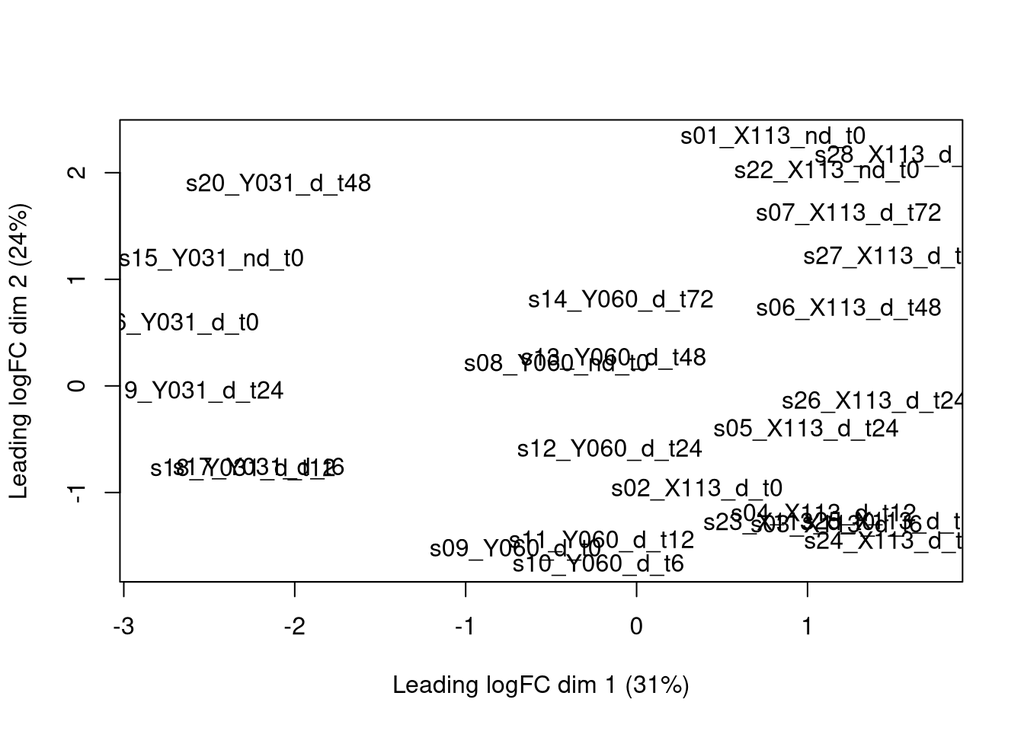

```r
plotMDS(counts_no72_Y031.asDGEList)
```

## *Box plots*

*Figure 3 g, j and Sfigure 3 c, e*

```r
#| label: Fig 3 g, j


# Define genes of interest
basal_list <- data.frame(
  gene = c(
    "EPS8L1",
    "THBS1",
    "PLAUR",
    "EBI3"
  )
)

# Define the desired timepoint order
time_order <- c("nd_t0", "d_t0", "d_t6", "d_t12", "d_t24", "d_t48", "d_t72")
custom_colors <- c(
  "nd_t0" = 'grey60',
  "d_t0" = '#C49A00',
  "d_t6" = '#53B400',
  "d_t12" = '#00C094',
  "d_t24" = '#00B6EB',
  "d_t48" = '#A58AFF',
  "d_t72" = '#FB61D7'
)

# Loop through each gene of interest
for (i in seq_len(nrow(basal_list))) {

  mygene <- basal_list$gene[i]

  # Check if gene exists in the expression matrix
  if (!(mygene %in% rownames(counts_no72_Y031.asDGEList.cpm))) {
    warning(paste("Gene", mygene, "not found in expression matrix. Skipping."))
    next
  }

  myENTREZ <- as.character(na.omit(all_counts_orig$uniqueID[all_counts_orig$SYMBOL == mygene]))
  expr.values <- counts_no72_Y031.asDGEList.cpm[mygene, ]

  df2plot <- data.frame(samples = colnames(counts_no72_Y031.asDGEList.cpm), cpm = expr.values)
  df2plot_withMetadata <- merge(df2plot, metadata_no72_Y031, by.x = "samples", by.y = 0, sort = FALSE)

  # Create a new column for time group from sample names
  df2plot_withMetadata$time_group <- gsub(".*_(nd|d)_t(\\d+)", "\\1_t\\2", df2plot_withMetadata$samples)
  df2plot_withMetadata$time_group <- factor(df2plot_withMetadata$time_group, levels = time_order)

  # Save plot as TIFF
  tiff(filename = paste0(plot_dir, "/", mygene, ".tiff"), width = 3200, height = 2400, res = 300)

p <- ggplot(df2plot_withMetadata, aes(x = time_group, y = cpm, fill = time_group)) +
    geom_boxplot(outlier.shape = NA, color = "black") +
    geom_jitter(aes(shape = donor3, fill = time_group),
                position = position_jitterdodge(jitter.width = 0.2, dodge.width = 0.6),
                size = 4, stroke = 1, color = "black") +
    scale_shape_manual(values = c(21, 22, 23, 24)) +
    scale_fill_manual(values = custom_colors) +
    labs(
      title = paste(myENTREZ, " ('", mygene, "')"),
      x = "Time Group", y = "CPM"
    ) +
    theme_bw(base_size = 15) +
    theme(axis.text.x = element_text(size = 13))

  print(p)
  dev.off()
}
```

## *Setting up the design matrix*

*before damage*

```r
t0_nd <- damaged== "nd" & time == "t0"
```

*T0*

```r
t0_d <- damaged== "d" & time == "t0"
```

*T6*

```r
t6_d <- damaged== "d" & time == "t6"
```

*T12*

```r
t12_d <- damaged== "d" & time == "t12"
```

*T24*

```r
t24_d <- damaged== "d" & time == "t24"
```

*T48*

```r
t48_d <- damaged== "d" & time == "t48"
```

*T72*

```r
t72_d <- damaged== "d" & time == "t72"
```

## *Volcano plots where we compare to Before Damage*

```r
design <- model.matrix(~donor3 + t0_d + t6_d + t12_d + t24_d + t48_d + t72_d)

rownames(design) <- colnames(counts_no72_Y031.asDGEList)
design
```

```
               (Intercept) donor3X113_3797 donor3Y031_3797 donor3Y060_3797
s01_X113_nd_t0           1               1               0               0
s02_X113_d_t0            1               1               0               0
s03_X113_d_t6            1               1               0               0
s04_X113_d_t12           1               1               0               0
s05_X113_d_t24           1               1               0               0
s06_X113_d_t48           1               1               0               0
s07_X113_d_t72           1               1               0               0
s08_Y060_nd_t0           1               0               0               1
s09_Y060_d_t0            1               0               0               1
s10_Y060_d_t6            1               0               0               1
s11_Y060_d_t12           1               0               0               1
s12_Y060_d_t24           1               0               0               1
s13_Y060_d_t48           1               0               0               1
s14_Y060_d_t72           1               0               0               1
s15_Y031_nd_t0           1               0               1               0
s16_Y031_d_t0            1               0               1               0
s17_Y031_d_t6            1               0               1               0
s18_Y031_d_t12           1               0               1               0
s19_Y031_d_t24           1               0               1               0
s20_Y031_d_t48           1               0               1               0
s22_X113_nd_t0           1               0               0               0
s23_X113_d_t0            1               0               0               0
s24_X113_d_t6            1               0               0               0
s25_X113_d_t12           1               0               0               0
s26_X113_d_t24           1               0               0               0
s27_X113_d_t48           1               0               0               0
s28_X113_d_t72           1               0               0               0
               t0_dTRUE t6_dTRUE t12_dTRUE t24_dTRUE t48_dTRUE t72_dTRUE
s01_X113_nd_t0        0        0         0         0         0         0
s02_X113_d_t0         1        0         0         0         0         0
s03_X113_d_t6         0        1         0         0         0         0
s04_X113_d_t12        0        0         1         0         0         0
s05_X113_d_t24        0        0         0         1         0         0
s06_X113_d_t48        0        0         0         0         1         0
s07_X113_d_t72        0        0         0         0         0         1
s08_Y060_nd_t0        0        0         0         0         0         0
s09_Y060_d_t0         1        0         0         0         0         0
s10_Y060_d_t6         0        1         0         0         0         0
s11_Y060_d_t12        0        0         1         0         0         0
```

[output cut: 24 more lines]

```

attr(,"contrasts")$t6_d
[1] "contr.treatment"

attr(,"contrasts")$t12_d
[1] "contr.treatment"

attr(,"contrasts")$t24_d
[1] "contr.treatment"

attr(,"contrasts")$t48_d
[1] "contr.treatment"

attr(,"contrasts")$t72_d
[1] "contr.treatment"
```

### *Dispersion estimation*

```r
counts_no72_Y031.asDGEList.disp <- estimateDisp(counts_no72_Y031.asDGEList, design, robust = TRUE)
counts_no72_Y031.asDGEList.disp$common.dispersion
```

```
[1] 0.03323518
```

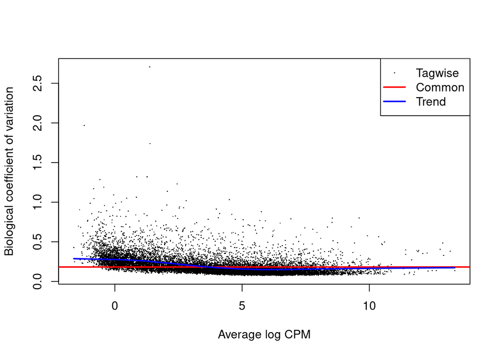

```r
plotBCV(counts_no72_Y031.asDGEList.disp)
```

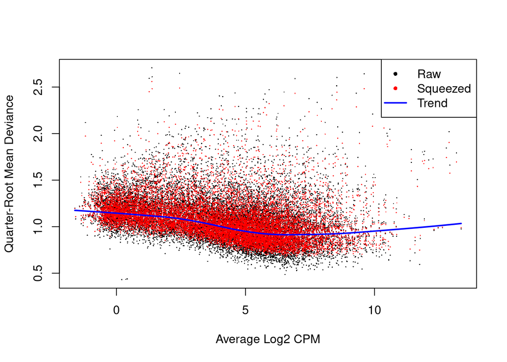

```r
fit <- glmQLFit(counts_no72_Y031.asDGEList.disp, design)

plotQLDisp(fit)
```

### *Differential expression*

#### *Damage time 0 vs Before damage*

*Supplemental Figure 3 a and Supplemental Table S3*

```r
qlf_1 <- glmQLFTest(fit, contrast=as.vector((colnames(design) == "t0_dTRUE") * +1 ))
topTags(qlf_1)
```

```
Coefficient:  1*t0_dTRUE
                             uniqueID         ENSEMBL  SYMBOL
EGR1                             EGR1 ENSG00000120738    EGR1
NA_ENSG00000226548 NA_ENSG00000226548 ENSG00000226548    <NA>
RELL2                           RELL2 ENSG00000164620   RELL2
SAXO3                           SAXO3 ENSG00000268655   SAXO3
STRA6                           STRA6 ENSG00000137868   STRA6
FOS                               FOS ENSG00000170345     FOS
HLF                               HLF ENSG00000108924     HLF
TRIM40                         TRIM40 ENSG00000204614  TRIM40
DENND2D                       DENND2D ENSG00000162777 DENND2D
THEM5                           THEM5 ENSG00000196407   THEM5
                                                                GENENAME width
EGR1                                             early growth response 1  3137
NA_ENSG00000226548                                                  <NA>   652
RELL2                                                        RELT like 2  2583
SAXO3                              stabilizer of axonemal microtubules 3  1756
STRA6                signaling receptor and transporter of retinol STRA6  7669
FOS                Fos proto-oncogene, AP-1 transcription factor subunit  3186
HLF                     HLF transcription factor, PAR bZIP family member  6776
TRIM40                                    tripartite motif containing 40  2481
DENND2D                                        DENN domain containing 2D  6677
THEM5                                  thioesterase superfamily member 5  1161
                       logFC     logCPM         F       PValue          FDR
EGR1                5.121836  4.3941363 221.99328 6.037766e-13 9.315669e-09
NA_ENSG00000226548 -4.396504 -1.2824154  79.37523 1.384211e-10 9.545637e-07
RELL2              -2.508832  3.6832369 122.98883 1.856045e-10 9.545637e-07
SAXO3              -5.067644  2.6623696 118.02330 2.739720e-10 1.056779e-06
STRA6              -3.878566  3.9994743 111.70573 4.550055e-10 1.404056e-06
FOS                 5.214548  5.5149227 107.25143 6.614252e-10 1.700855e-06
HLF                -5.794939  0.7517075  74.62261 9.724169e-10 2.141986e-06
TRIM40             -4.921559  0.8148066  76.10370 1.110629e-09 2.141986e-06
DENND2D            -2.606562  4.0860713  98.11846 1.487113e-09 2.480975e-06
THEM5              -4.712303  3.5254012  97.68745 1.607995e-09 2.480975e-06
```

```r
tt_1 <- as.data.frame(topTags(qlf_1,n=nrow(counts_no72_Y031.asDGEList)))

# Modify the status column based on logFC and FDR
tt_modified_1 <- tt_1 %>%
  mutate(status = factor(case_when(
    logFC > 2 & FDR < 0.05 ~ "up",
    logFC < (-2) & FDR < 0.05 ~ "down",
    TRUE ~ "ns"
  ), levels = c("up", "ns", "down")))


write.csv(tt_modified_1, file = paste0(table_dir, "/D0 vs BD.csv"), row.names = FALSE)

# Create the volcano plot with -log10(PValue) on the y-axis
vplot <- ggplot(tt_modified_1, aes(x = logFC, y = -log10(PValue), color = status)) +
  geom_point(size = 1) +
  scale_color_manual(values = c("firebrick", "grey", "dodgerblue")) +
  ggtitle("D0 vs ND0; logFC > |2|, logCPM > 1, PValue < 0.05") +
  theme(plot.title = element_text(size = 30, face = "bold.italic"),
        axis.title = element_text(size = 30, face = "bold"),
        axis.text = element_text(size = 30)) +
  guides(color = guide_legend(override.aes = list(size = 4))) +
  theme_bw() +
  geom_hline(yintercept = -log10(0.00660125146985328), linetype = "dashed", color = "black") +
  geom_vline(xintercept = 2, linetype = "dashed", color = "black") +
  geom_vline(xintercept = -2, linetype = "dashed", color = "black") +
  geom_label_repel(data = tt_modified_1 %>% filter(SYMBOL %in% c("EGR1", "FOS", "JUN", "FOSB", "CSHL1", "CGB1", "CGB5", "TCL1B", "SDC1", "PSG8", "CYP19A1", "TWIST1", "INSL4", "SLC26A1", "S100P", "CXCL11", "ENDOU", size = 7 )), aes(label = SYMBOL), size = 6,
                   box.padding = 0.5,
                   point.padding = 0.5,
                   max.overlaps = Inf,
                   segment.color = 'grey50'
  )



tiff(paste0(plot_dir, "/SuppFigure_3_a1.tiff"), width = 10, height = 8, units = "in", res = 300)
print(vplot)
dev.off()
```

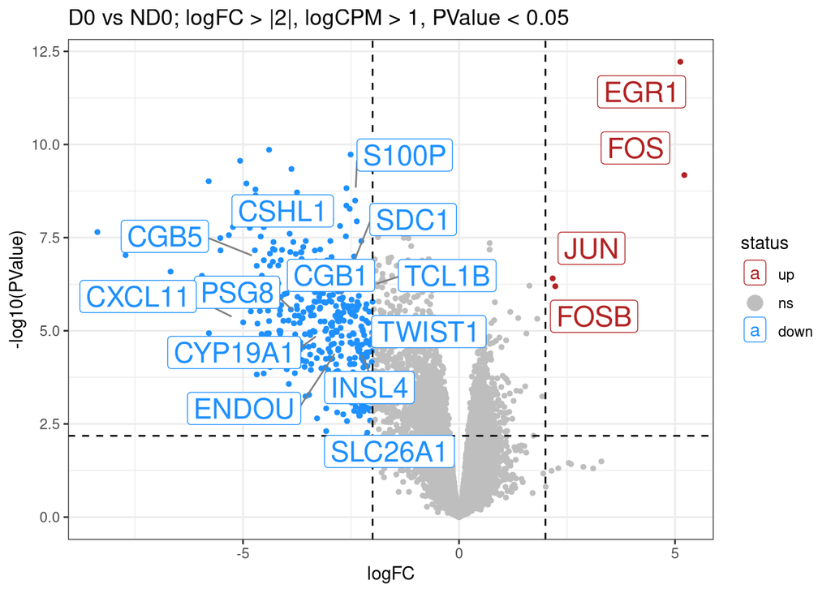

```r
# Display the plot
print(vplot)
```

#### *Damage time 72 vs Before damage*

*Supplemental Figure 3 a and Supplemental Table S3*

```r
qlf_7 <- glmQLFTest(fit,contrast=as.vector((colnames(design) == "t72_dTRUE") * +1) )

topTags(qlf_7)
```

```
Coefficient:  1*t72_dTRUE
                             uniqueID         ENSEMBL   SYMBOL
IFI27                           IFI27 ENSG00000165949    IFI27
LGALS3BP                     LGALS3BP ENSG00000108679 LGALS3BP
NA_ENSG00000281162 NA_ENSG00000281162 ENSG00000281162     <NA>
OAS1                             OAS1 ENSG00000089127     OAS1
UBE2L6                         UBE2L6 ENSG00000156587   UBE2L6
IRF7                             IRF7 ENSG00000185507     IRF7
RASGRF2                       RASGRF2 ENSG00000113319  RASGRF2
IL2RG                           IL2RG ENSG00000147168    IL2RG
IRF9                             IRF9 ENSG00000213928     IRF9
MACC1                           MACC1 ENSG00000183742    MACC1
                                                                     GENENAME
IFI27                                   interferon alpha inducible protein 27
LGALS3BP                                           galectin 3 binding protein
NA_ENSG00000281162                                                       <NA>
OAS1                                        2'-5'-oligoadenylate synthetase 1
UBE2L6                                     ubiquitin conjugating enzyme E2 L6
IRF7                                           interferon regulatory factor 7
RASGRF2            Ras protein specific guanine nucleotide releasing factor 2
IL2RG                                    interleukin 2 receptor subunit gamma
IRF9                                           interferon regulatory factor 9
MACC1                                     MET transcriptional regulator MACC1
                   width    logFC     logCPM         F       PValue
IFI27               4147 3.870256  3.9377419 114.35099 3.695764e-10
LGALS3BP            3422 1.130364  9.3639627  93.14395 2.373059e-09
NA_ENSG00000281162  3841 4.339207  0.7212212  78.07199 4.686227e-09
OAS1               13021 3.055783  4.3745798  84.73337 5.501698e-09
UBE2L6              2062 2.285096  4.0041892  84.27267 5.773393e-09
IRF7                2612 1.759690  5.2323089  83.49345 6.260491e-09
RASGRF2            11032 3.215009 -0.5416004  62.30762 6.406170e-09
IL2RG               2760 3.625270 -0.2358838  73.34450 6.971164e-09
IRF9                3582 1.426376  5.6429210  81.24076 7.953097e-09
MACC1               9898 1.634650  3.0846625  80.49001 8.656904e-09
                            FDR
IFI27              5.702195e-06
LGALS3BP           1.311134e-05
NA_ENSG00000281162 1.311134e-05
OAS1               1.311134e-05
UBE2L6             1.311134e-05
IRF7               1.311134e-05
RASGRF2            1.311134e-05
IL2RG              1.311134e-05
IRF9               1.311134e-05
MACC1              1.311134e-05
```

```r
tt_7 <- as.data.frame(topTags(qlf_7,n=nrow(counts_no72_Y031.asDGEList)))

# Modify the status column based on logFC and FDR
tt_modified_7 <- tt_7 %>%
  mutate(status = factor(case_when(
    logFC > 2 & FDR < 0.05 ~ "up",
    logFC < (-2) & FDR < 0.05 ~ "down",
    TRUE ~ "ns"
  ), levels = c("up", "ns", "down")))


write.csv(tt_modified_7, file = paste0(table_dir, "/D72 vs BD.csv"), row.names = FALSE)

# Create the volcano plot with -log10(PValue) on the y-axis
vplot <- ggplot(tt_modified_7, aes(x = logFC, y = -log10(PValue), color = status)) +
  geom_point(size = 1) +
  scale_color_manual(values = c("firebrick", "grey", "dodgerblue")) +
  ggtitle("ND0 vs D72; logFC > |2|, logCPM > 1, PValue < 0.05") +
    theme(plot.title = element_text(size = 30, face = "bold.italic"),
        axis.title = element_text(size = 30, face = "bold"),
        axis.text = element_text(size = 30)) +
  guides(color = guide_legend(override.aes = list(size = 4))) +
  theme_bw() +
  geom_hline(yintercept = -log10(0.00641132371289005), linetype = "dashed", color = "black") +
  geom_vline(xintercept = 2, linetype = "dashed", color = "black") +
  geom_vline(xintercept = -2, linetype = "dashed", color = "black") +
  geom_label_repel(data = tt_modified_7 %>% filter(SYMBOL %in% c("APOA2", "IFI27", "FAM86JP", "IGFBP3", "PALD1", "SPNS2", "FAM71F1",
                         "IL2RG", "RNF157", "PNCK", "PLAC8", "SLC6A8", "IFITM1", "SLCO4A1",
                         "IFIT1", "IL31RA", "XAF1", "PAPPA2", "VTCN1",
 size = 7)
), aes(label = SYMBOL), size = 6,
                   box.padding = 0.5,
                   point.padding = 0.5,
                   max.overlaps = Inf,
                   segment.color = 'grey50'
  )

# Save the plot
tiff(paste0(plot_dir, "/SuppFigure_3_a3.tiff"), width = 10, height = 8, units = "in", res = 300)
print(vplot)
dev.off()
```

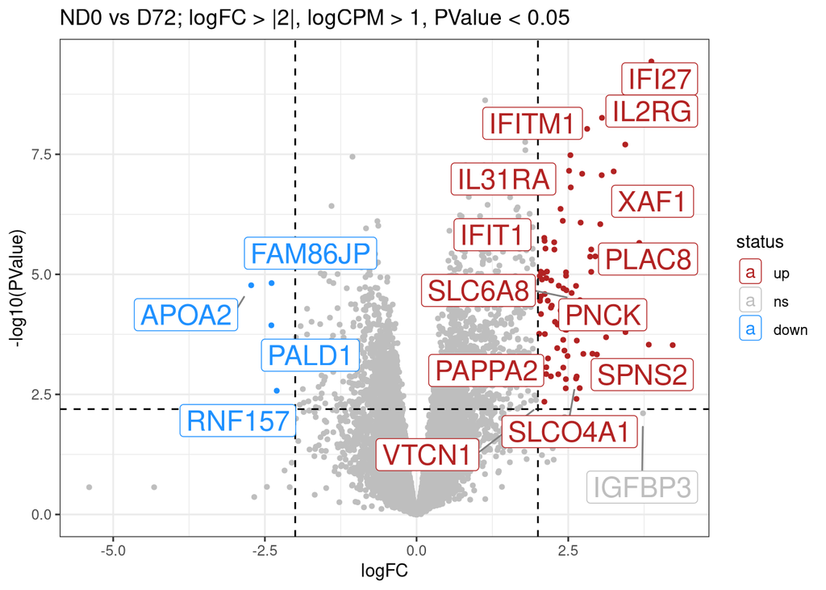

```r
# Display the plot
print(vplot)
```

## *Volcano plots where we compare to Damage time 0*

*New model.matrix (do not include MG.21p.5)*

```r
design <- model.matrix(~donor3 + t0_nd + t6_d + t12_d + t24_d + t48_d + t72_d)

rownames(design) <- colnames(counts_no72_Y031.asDGEList)
design
```

```
               (Intercept) donor3X113_3797 donor3Y031_3797 donor3Y060_3797
s01_X113_nd_t0           1               1               0               0
s02_X113_d_t0            1               1               0               0
s03_X113_d_t6            1               1               0               0
s04_X113_d_t12           1               1               0               0
s05_X113_d_t24           1               1               0               0
s06_X113_d_t48           1               1               0               0
s07_X113_d_t72           1               1               0               0
s08_Y060_nd_t0           1               0               0               1
s09_Y060_d_t0            1               0               0               1
s10_Y060_d_t6            1               0               0               1
s11_Y060_d_t12           1               0               0               1
s12_Y060_d_t24           1               0               0               1
s13_Y060_d_t48           1               0               0               1
s14_Y060_d_t72           1               0               0               1
s15_Y031_nd_t0           1               0               1               0
s16_Y031_d_t0            1               0               1               0
s17_Y031_d_t6            1               0               1               0
s18_Y031_d_t12           1               0               1               0
s19_Y031_d_t24           1               0               1               0
s20_Y031_d_t48           1               0               1               0
s22_X113_nd_t0           1               0               0               0
s23_X113_d_t0            1               0               0               0
s24_X113_d_t6            1               0               0               0
s25_X113_d_t12           1               0               0               0
s26_X113_d_t24           1               0               0               0
s27_X113_d_t48           1               0               0               0
s28_X113_d_t72           1               0               0               0
               t0_ndTRUE t6_dTRUE t12_dTRUE t24_dTRUE t48_dTRUE t72_dTRUE
s01_X113_nd_t0         1        0         0         0         0         0
s02_X113_d_t0          0        0         0         0         0         0
s03_X113_d_t6          0        1         0         0         0         0
s04_X113_d_t12         0        0         1         0         0         0
s05_X113_d_t24         0        0         0         1         0         0
s06_X113_d_t48         0        0         0         0         1         0
s07_X113_d_t72         0        0         0         0         0         1
s08_Y060_nd_t0         1        0         0         0         0         0
s09_Y060_d_t0          0        0         0         0         0         0
s10_Y060_d_t6          0        1         0         0         0         0
s11_Y060_d_t12         0        0         1         0         0         0
```

[output cut: 24 more lines]

```

attr(,"contrasts")$t6_d
[1] "contr.treatment"

attr(,"contrasts")$t12_d
[1] "contr.treatment"

attr(,"contrasts")$t24_d
[1] "contr.treatment"

attr(,"contrasts")$t48_d
[1] "contr.treatment"

attr(,"contrasts")$t72_d
[1] "contr.treatment"
```

### *Dispersion estimation and fitting*

```r
counts_no72_Y031.asDGEList.disp <- estimateDisp(counts_no72_Y031.asDGEList, design, robust = TRUE)
counts_no72_Y031.asDGEList.disp$common.dispersion
```

[output not shown]

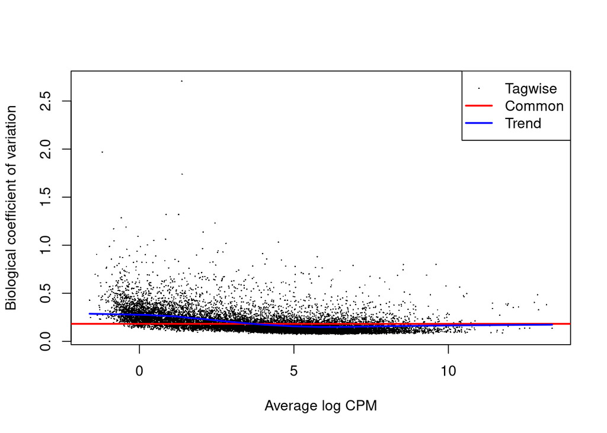

```r
plotBCV(counts_no72_Y031.asDGEList.disp)
```

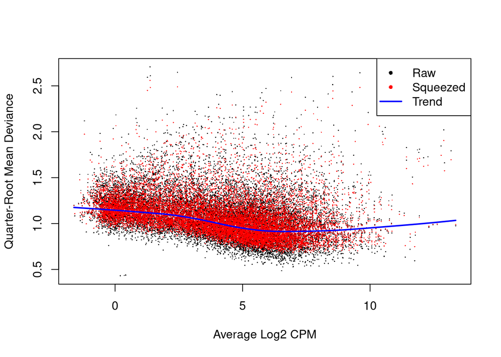

```r
fit <- glmQLFit(counts_no72_Y031.asDGEList.disp, design)

plotQLDisp(fit)
```

### *Differential expression*

#### *Damage time 6 vs Damage time 0*

*Supplemental Table S3*

```r
qlf_2 <- glmQLFTest(fit, contrast=as.vector((colnames(design) == "t6_dTRUE") * +1 ))
topTags(qlf_2)
```

```
Coefficient:  1*t6_dTRUE
         uniqueID         ENSEMBL   SYMBOL
KRT14       KRT14 ENSG00000186847    KRT14
ABCG1       ABCG1 ENSG00000160179    ABCG1
ACTG2       ACTG2 ENSG00000163017    ACTG2
SH3BGRL3 SH3BGRL3 ENSG00000142669 SH3BGRL3
TEF           TEF ENSG00000167074      TEF
KRT18       KRT18 ENSG00000111057    KRT18
EPS8         EPS8 ENSG00000151491     EPS8
TBC1D5     TBC1D5 ENSG00000131374   TBC1D5
IGFBP4     IGFBP4 ENSG00000141753   IGFBP4
EGR1         EGR1 ENSG00000120738     EGR1
                                                 GENENAME width     logFC
KRT14                                          keratin 14  2255  5.243483
ABCG1           ATP binding cassette subfamily G member 1  6121 -3.275884
ACTG2                        actin gamma 2, smooth muscle  3811  4.637869
SH3BGRL3 SH3 domain binding glutamate rich protein like 3   876  1.538214
TEF      TEF transcription factor, PAR bZIP family member  4702 -2.412379
KRT18                                          keratin 18  3069  1.674932
EPS8          EGFR pathway substrate 8, signaling adaptor  8540 -2.216292
TBC1D5                        TBC1 domain family member 5 11269 -1.450837
IGFBP4       insulin like growth factor binding protein 4  2205  2.359213
EGR1                              early growth response 1  3137 -4.985416
             logCPM        F       PValue          FDR
KRT14     2.4940871 275.5055 1.918520e-14 2.876756e-10
ABCG1     4.1047831 292.0064 3.729025e-14 2.876756e-10
ACTG2     0.2547326 165.4304 7.479634e-14 3.846776e-10
SH3BGRL3  5.6238455 256.8799 1.370031e-13 5.284551e-10
TEF       3.8980948 251.2018 1.719601e-13 5.306345e-10
KRT18    11.5763640 244.0355 2.301835e-13 5.919169e-10
EPS8      4.1069410 232.8662 3.693056e-13 8.140022e-10
TBC1D5    5.8128393 229.1383 4.340627e-13 8.371442e-10
IGFBP4    3.3867821 224.9224 5.240114e-13 8.954195e-10
EGR1      4.3941363 222.8725 5.803483e-13 8.954195e-10
```

```r
summary(decideTests(qlf_2))
```

```
       1*t6_dTRUE
Down         3075
NotSig       9137
Up           3217
```

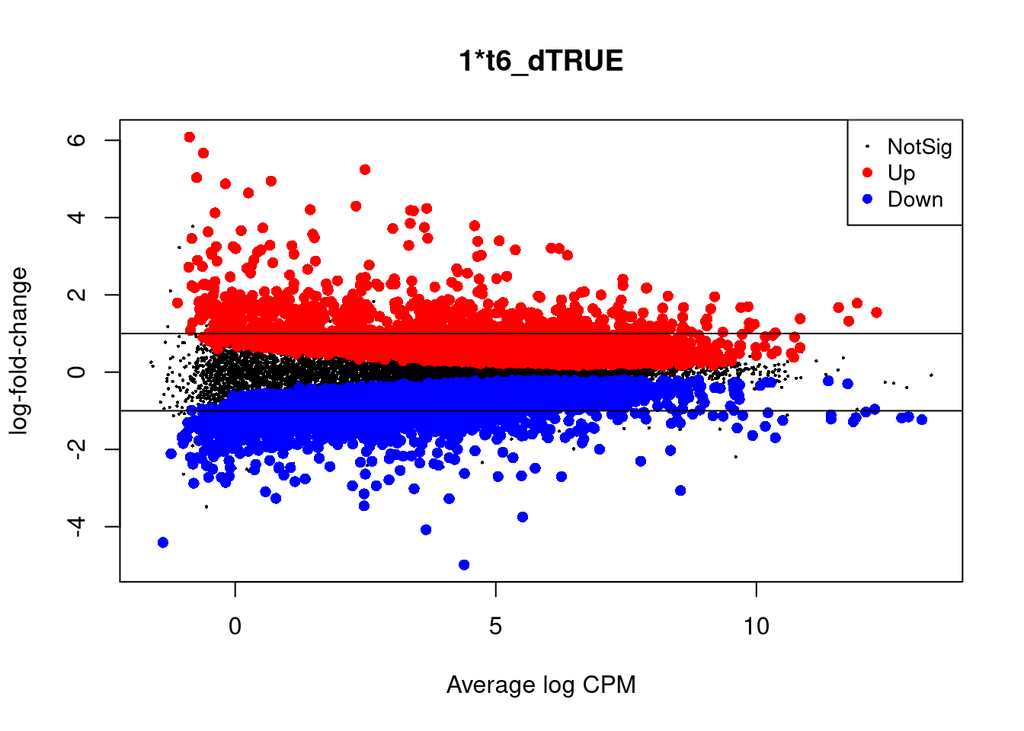

```r
plotMD(qlf_2)
abline(h=c(-1, 1), col="black")
```

```r
tt_2 <- as.data.frame(topTags(qlf_2,n=nrow(counts_no72_Y031.asDGEList)))


# Modify the status column based on logFC and FDR
tt_modified_2 <- tt_2 %>%
  mutate(status = factor(case_when(
    logFC > 2 & FDR < 0.05 ~ "up",
    logFC < (-2) & FDR < 0.05 ~ "down",
    TRUE ~ "ns"
  ), levels = c("up", "ns", "down")))

write.csv(tt_modified_2, file = paste0(table_dir, "/D6 vs D0.csv"), row.names = FALSE)

# Create the volcano plot with -log10(PValue) on the y-axis
vplot <- ggplot(tt_modified_2, aes(x = logFC, y = -log10(PValue), color = status)) +
  geom_point(size = 1) +
  scale_color_manual(values = c("firebrick", "grey", "dodgerblue")) +
  ggtitle("D0 versus T6; logFC > |2|, logCPM > 1, PValue < 0.05") +
    theme(plot.title = element_text(size = 30, face = "bold.italic"),
        axis.title = element_text(size = 30, face = "bold"),
        axis.text = element_text(size = 30)) +
  guides(color = guide_legend(override.aes = list(size = 4))) +
  theme_bw() +
  geom_hline(yintercept = -log10(0.0168406137075142), linetype = "dashed", color = "black") +
  geom_vline(xintercept = 2, linetype = "dashed", color = "black") +
  geom_vline(xintercept = -2, linetype = "dashed", color = "black") +
  geom_label_repel(data = tt_modified_2 %>% filter(SYMBOL %in% c("EGR1", "KRT14", "FOS", "SIRPB2", "VTN", "KRT17", "FIGNL2", "THBS1",
                         "CDKN2C", "IL12RB2", "CCNG2", "TSC22D3", "CD69", "ITGA2", "AXL",
                         "IL6", "PLAUR", "IGFBP4", "TNFRSF12A", "GPRC5A", "SOX12", "SPHK1", size = 7)
), aes(label = SYMBOL), size = 6,
                   box.padding = 0.5,
                   point.padding = 0.5,
                   max.overlaps = Inf,
                   segment.color = 'grey50'
  )

# Save the plot
#tiff(paste0(plot_dir, "/Figure_4_d.tiff"), width = 10, height = 8, units = "in", res = 300)
#print(vplot)
#dev.off()

# Display the plot
#print(vplot)
```

#### *Damage time 12 vs Damage time 0*

*Supplemental Table S3*

```r
qlf_3 <- glmQLFTest(fit, contrast=as.vector((colnames(design) == "t12_dTRUE") * + 1 ))
topTags(qlf_3)
```

```
Coefficient:  1*t12_dTRUE
         uniqueID         ENSEMBL   SYMBOL
KRT14       KRT14 ENSG00000186847    KRT14
ABCG1       ABCG1 ENSG00000160179    ABCG1
ACTG2       ACTG2 ENSG00000163017    ACTG2
SH3BGRL3 SH3BGRL3 ENSG00000142669 SH3BGRL3
EGR1         EGR1 ENSG00000120738     EGR1
GAL           GAL ENSG00000069482      GAL
KRT18       KRT18 ENSG00000111057    KRT18
KRT18P28 KRT18P28 ENSG00000176855 KRT18P28
MYL9         MYL9 ENSG00000101335     MYL9
SERPINB7 SERPINB7 ENSG00000166396 SERPINB7
                                                 GENENAME width     logFC
KRT14                                          keratin 14  2255  5.432450
ABCG1           ATP binding cassette subfamily G member 1  6121 -2.970351
ACTG2                        actin gamma 2, smooth muscle  3811  4.527397
SH3BGRL3 SH3 domain binding glutamate rich protein like 3   876  1.409266
EGR1                              early growth response 1  3137 -4.769467
GAL                        galanin and GMAP prepropeptide  1300  4.751773
KRT18                                          keratin 18  3069  1.455892
KRT18P28                         keratin 18 pseudogene 28  1332  1.664840
MYL9                                 myosin light chain 9  2808  2.667824
SERPINB7                         serpin family B member 7  2637  1.787266
             logCPM        F       PValue          FDR
KRT14     2.4940871 301.9524 7.090944e-15 1.094062e-10
ABCG1     4.1047831 258.4150 1.294360e-13 8.053171e-10
ACTG2     0.2547326 156.2137 1.565851e-13 8.053171e-10
SH3BGRL3  5.6238455 217.1478 7.438379e-13 2.869169e-09
EGR1      4.3941363 209.3418 1.084771e-12 3.347385e-09
GAL       0.6881826 172.0264 2.139576e-12 5.501921e-09
KRT18    11.5763640 186.8110 3.314395e-12 7.244220e-09
KRT18P28  4.3140332 184.4601 3.756158e-12 7.244220e-09
MYL9      2.5702701 170.1552 8.650644e-12 1.483009e-08
SERPINB7  5.1414727 157.7421 1.732071e-11 2.613831e-08
```

```r
tt_3 <- as.data.frame(topTags(qlf_3,n=nrow(counts_no72_Y031.asDGEList)))


# Modify the status column based on logFC and FDR
tt_modified_3 <- tt_3 %>%
  mutate(status = factor(case_when(
    logFC > 2 & FDR < 0.05 ~ "up",
    logFC < (-2) & FDR < 0.05 ~ "down",
    TRUE ~ "ns"
  ), levels = c("up", "ns", "down")))



write.csv(tt_modified_3, file = paste0(table_dir, "/D12 vs D0.csv"), row.names = FALSE)

# Create the volcano plot with -log10(PValue) on the y-axis
vplot <- ggplot(tt_modified_3, aes(x = logFC, y = -log10(PValue), color = status)) +
  geom_point(size = 1) +
  scale_color_manual(values = c("firebrick", "grey", "dodgerblue")) +
  ggtitle("D12 vs D0; logFC > |2|, logCPM > 1, PValue < 0.05") +
    theme(plot.title = element_text(size = 30, face = "bold.italic"),
        axis.title = element_text(size = 30, face = "bold"),
        axis.text = element_text(size = 30)) +
  guides(color = guide_legend(override.aes = list(size = 4))) +
  theme_bw() +
  geom_hline(yintercept = -log10(0.0165027508617822), linetype = "dashed", color = "black") +
  geom_vline(xintercept = 2, linetype = "dashed", color = "black") +
  geom_vline(xintercept = -2, linetype = "dashed", color = "black") +
  geom_label_repel(data = tt_modified_3 %>% filter(SYMBOL %in%  c("EGR1", "KRT14", "FOS", "THBS1", "FOSB", "GPRC5A", "CDKN2C", "ITGA2",
 "VTN", "IL12RB2", "GH2", "KRT17", "SIRPB2", "AXL", "IL1R2", "ITGA1",
 "CYP1A1", "NOG", "SPRR3", "FGF1", "RBP4", size = 7)
), aes(label = SYMBOL), size = 6,
                   box.padding = 0.5,
                   point.padding = 0.5,
                   max.overlaps = Inf,
                   segment.color = 'grey50'
  )

# Save the plot
#tiff(paste0(plot_dir, "/Figure_4_e.tiff"), width = 10, height = 8, units = "in", res = 300)
#print(vplot)
#dev.off()


# Display the plot
#print(vplot)
```

#### *Damage time 24 vs Damage time 0*

*Supplemental Figure 3 a and Supplemental Table S3*

```r
qlf_4 <- glmQLFTest(fit, contrast=as.vector((colnames(design) == "t24_dTRUE") * + 1 ))
topTags(qlf_4)
```

```
Coefficient:  1*t24_dTRUE
         uniqueID         ENSEMBL   SYMBOL
EGR1         EGR1 ENSG00000120738     EGR1
KRT14       KRT14 ENSG00000186847    KRT14
CNTNAP2   CNTNAP2 ENSG00000174469  CNTNAP2
SH3BGRL3 SH3BGRL3 ENSG00000142669 SH3BGRL3
KRT18       KRT18 ENSG00000111057    KRT18
FOS           FOS ENSG00000170345      FOS
LY6G6C     LY6G6C ENSG00000204421   LY6G6C
COCH         COCH ENSG00000100473     COCH
NUP210     NUP210 ENSG00000132182   NUP210
ADGRF4     ADGRF4 ENSG00000153294   ADGRF4
                                                      GENENAME width      logFC
EGR1                                   early growth response 1  3137 -4.6062146
KRT14                                               keratin 14  2255  3.7585270
CNTNAP2                         contactin associated protein 2 16377 -1.0518801
SH3BGRL3      SH3 domain binding glutamate rich protein like 3   876  0.9218024
KRT18                                               keratin 18  3069  1.0018534
FOS      Fos proto-oncogene, AP-1 transcription factor subunit  3186 -4.4706464
LY6G6C                  lymphocyte antigen 6 family member G6C  1004  1.8772436
COCH                                                   cochlin  4031 -1.0177471
NUP210                                         nucleoporin 210  8195 -1.0655590
ADGRF4                  adhesion G protein-coupled receptor F4  3391  1.5400055
            logCPM         F       PValue          FDR
EGR1      4.394136 202.22926 1.529709e-12 2.360188e-08
KRT14     2.494087 128.02510 5.705152e-11 4.401239e-07
CNTNAP2   3.857893  95.77497 1.848483e-09 8.335922e-06
SH3BGRL3  5.623846  94.12092 2.161105e-09 8.335922e-06
KRT18    11.576364  90.34336 3.117177e-09 9.618986e-06
FOS       5.514923  88.38294 3.793899e-09 9.756012e-06
LY6G6C    4.628625  86.13546 4.759647e-09 1.049094e-05
COCH      4.139702  82.27728 7.120773e-09 1.373330e-05
NUP210    6.776589  80.43506 8.675089e-09 1.446105e-05
ADGRF4    4.679769  79.72541 9.372642e-09 1.446105e-05
```

```r
tt_4 <- as.data.frame(topTags(qlf_4,n=nrow(counts_no72_Y031.asDGEList)))

# Modify the status column based on logFC and FDR
tt_modified_4 <- tt_4 %>%
  mutate(status = factor(case_when(
    logFC > 2 & FDR < 0.05 ~ "up",
    logFC < (-2) & FDR < 0.05 ~ "down",
    TRUE ~ "ns"
  ), levels = c("up", "ns", "down")))

write.csv(tt_modified_4, file = paste0(table_dir, "/D24 vs D0.csv"), row.names = FALSE)

# Create the volcano plot with -log10(PValue) on the y-axis
vplot <- ggplot(tt_modified_4, aes(x = logFC, y = -log10(PValue), color = status)) +
  geom_point(size = 1) +
  scale_color_manual(values = c("firebrick", "grey", "dodgerblue")) +
  ggtitle("D24 vs D0; logFC > |2|, logCPM > 1, PValue < 0.05") +
    theme(plot.title = element_text(size = 30, face = "bold.italic"),
        axis.title = element_text(size = 30, face = "bold"),
        axis.text = element_text(size = 30)) +
  guides(color = guide_legend(override.aes = list(size = 4))) +
  theme_bw() +
  geom_hline(yintercept = -log10(0.006211311), linetype = "dashed", color = "black") +
  geom_vline(xintercept = 2, linetype = "dashed", color = "black") +
  geom_vline(xintercept = -2, linetype = "dashed", color = "black") +
  geom_label_repel(data = tt_modified_4 %>% filter(SYMBOL %in%  c("EGR1", "KRT14", "FOS", "CYP1A1", "VTN", "ITGA1", "FOSB", "IFI27",
"JUN", "KRT17", "GPRC5A", "TCL1B", "STRA6", "ALPP", "DHRS9",
"PIK3AP1", "ALPG", size = 7 )), aes(label = SYMBOL), size = 6,
                   box.padding = 0.5,
                   point.padding = 0.5,
                   max.overlaps = Inf,
                   segment.color = 'grey50'
  )



# Save the plot
tiff(paste0(plot_dir, "/SuppFigure_3_a2.tiff"), width = 10, height = 8, units = "in", res = 300)
print(vplot)
dev.off()
```

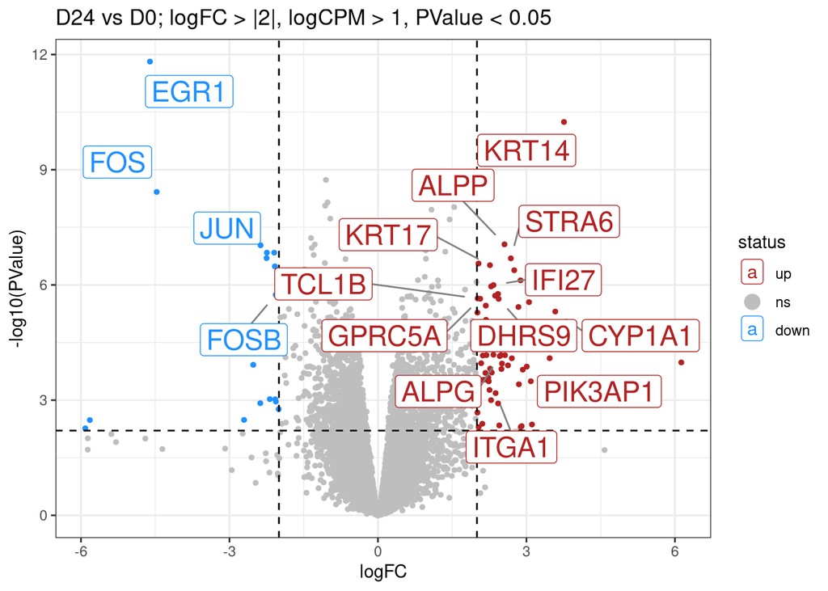

```r
# Display the plot
print(vplot)
```

#### *Damage time 48 vs Damage time 0*

*Supplemental Table S3*

```r
qlf_5 <- glmQLFTest(fit, contrast=as.vector((colnames(design) == "t48_dTRUE") * + 1 ))
topTags(qlf_5)
```

```
Coefficient:  1*t48_dTRUE
         uniqueID         ENSEMBL   SYMBOL
EGR1         EGR1 ENSG00000120738     EGR1
LY6G6C     LY6G6C ENSG00000204421   LY6G6C
KRT18P28 KRT18P28 ENSG00000176855 KRT18P28
KRT18       KRT18 ENSG00000111057    KRT18
STON2       STON2 ENSG00000140022    STON2
STRA6       STRA6 ENSG00000137868    STRA6
KRT8         KRT8 ENSG00000170421     KRT8
KRT8P3     KRT8P3 ENSG00000254285   KRT8P3
DENND2D   DENND2D ENSG00000162777  DENND2D
GDPD5       GDPD5 ENSG00000158555    GDPD5
                                                            GENENAME width
EGR1                                         early growth response 1  3137
LY6G6C                        lymphocyte antigen 6 family member G6C  1004
KRT18P28                                    keratin 18 pseudogene 28  1332
KRT18                                                     keratin 18  3069
STON2                                                       stonin 2  7812
STRA6            signaling receptor and transporter of retinol STRA6  7669
KRT8                                                       keratin 8  6881
KRT8P3                                        keratin 8 pseudogene 3  1449
DENND2D                                    DENN domain containing 2D  6677
GDPD5    glycerophosphodiester phosphodiesterase domain containing 5  9905
             logFC    logCPM         F       PValue          FDR
EGR1     -4.974761  4.394136 222.96545 5.779293e-13 8.916871e-09
LY6G6C    2.050103  4.628625 101.84275 1.059896e-09 5.483414e-06
KRT18P28  1.216403  4.314033  97.99424 1.503146e-09 5.483414e-06
KRT18     1.038931 11.576364  96.99911 1.647920e-09 5.483414e-06
STON2     1.671653  3.630555  96.19716 1.776983e-09 5.483414e-06
STRA6     3.514615  3.999474  94.23181 2.142584e-09 5.509654e-06
KRT8      1.212064 12.305824  91.30553 2.836169e-09 6.251321e-06
KRT8P3    1.243641  7.830007  89.35446 3.437982e-09 6.427753e-06
DENND2D   2.454488  4.086071  88.00884 3.937287e-09 6.427753e-06
GDPD5     2.567383  6.925694  87.44094 4.166021e-09 6.427753e-06
```

```r
tt_5 <- as.data.frame(topTags(qlf_5,n=nrow(counts_no72_Y031.asDGEList)))


# Modify the status column based on logFC and FDR
tt_modified_5 <- tt_5 %>%
  mutate(status = factor(case_when(
    logFC > 2 & FDR < 0.05 ~ "up",
    logFC < (-2) & FDR < 0.05 ~ "down",
    TRUE ~ "ns"
  ), levels = c("up", "ns", "down")))


write.csv(tt_modified_5, file = paste0(table_dir, "/D48 vs D0.csv"), row.names = FALSE)

# Create the volcano plot with -log10(PValue) on the y-axis
vplot <- ggplot(tt_modified_5, aes(x = logFC, y = -log10(PValue), color = status)) +
  geom_point(size = 1) +
  scale_color_manual(values = c("firebrick", "grey", "dodgerblue")) +
  ggtitle("D48 vs D0; logFC > |2|, logCPM > 1, PValue < 0.05") +
    theme(plot.title = element_text(size = 30, face = "bold.italic"),
        axis.title = element_text(size = 30, face = "bold"),
        axis.text = element_text(size = 30)) +
  guides(color = guide_legend(override.aes = list(size = 4))) +
  theme_bw() +
  geom_hline(yintercept = -log10(0.011593291980048), linetype = "dashed", color = "black") +
  geom_vline(xintercept = 2, linetype = "dashed", color = "black") +
  geom_vline(xintercept = -2, linetype = "dashed", color = "black") +
  geom_label_repel(data = tt_modified_5 %>% filter(SYMBOL %in% c("EGR1", "FOS", "JUN","CP", "TCL1B", "PSG9", "S100P", "SLC1A2", "CGB5", "MFSD2A", "ENDOU", "PSG4"  , size = 7, max.overlaps = Inf)
), aes(label = SYMBOL), size = 6,
                   box.padding = 0.5,
                   point.padding = 0.5,
                   max.overlaps = Inf,
                   segment.color = 'grey50'
  )

# Save the plot
#tiff(paste0(plot_dir, "/SuppFigure_3_d.tiff"), width = 10, height = 8, units = "in", res = 300)
#print(vplot)
#dev.off()

# Display the plot
#print(vplot)
#getwd()
```

#### *Damage time 72 vs Damage time 0*

*Supplemental Table S3*

```r
qlf_6 <- glmQLFTest(fit, contrast=as.vector((colnames(design) == "t72_dTRUE") * + 1 ))
topTags(qlf_6)
```

```
Coefficient:  1*t72_dTRUE
                             uniqueID         ENSEMBL    SYMBOL
RPL3L                           RPL3L ENSG00000140986     RPL3L
NA_ENSG00000185168 NA_ENSG00000185168 ENSG00000185168      <NA>
EGR1                             EGR1 ENSG00000120738      EGR1
TRIM40                         TRIM40 ENSG00000204614    TRIM40
SAXO3                           SAXO3 ENSG00000268655     SAXO3
FAM151AP1                   FAM151AP1 ENSG00000234805 FAM151AP1
IFI27                           IFI27 ENSG00000165949     IFI27
RELL2                           RELL2 ENSG00000164620     RELL2
KRT18                           KRT18 ENSG00000111057     KRT18
LINC00323                   LINC00323 ENSG00000226496 LINC00323
                                                                  GENENAME
RPL3L                                            ribosomal protein L3 like
NA_ENSG00000185168                                                    <NA>
EGR1                                               early growth response 1
TRIM40                                      tripartite motif containing 40
SAXO3                                stabilizer of axonemal microtubules 3
FAM151AP1          family with sequence similarity 151 member A pseudogene
IFI27                                interferon alpha inducible protein 27
RELL2                                                          RELT like 2
KRT18                                                           keratin 18
LINC00323                       long intergenic non-protein coding RNA 323
                   width     logFC     logCPM         F       PValue
RPL3L               2758  5.380183  0.1003221 142.14833 1.334762e-12
NA_ENSG00000185168  2197  3.093501  3.0956283 185.38463 3.583618e-12
EGR1                3137 -4.666551  4.3941363 165.42626 1.101850e-11
TRIM40              2481  5.774554  0.8148068 100.95808 4.714747e-11
SAXO3               1756  5.616288  2.6623697 137.55545 6.479709e-11
FAM151AP1           1834  4.606678 -0.8761085  98.06435 6.651436e-11
IFI27               4147  4.221950  3.9377420 134.60837 8.010604e-11
RELL2               2583  2.772925  3.6832369 134.13957 8.188656e-11
KRT18               3069  1.291312 11.5763640 129.63238 1.130436e-10
LINC00323           2570  5.853618  1.1181861  91.69065 1.284220e-10
                            FDR
RPL3L              2.059405e-08
NA_ENSG00000185168 2.764582e-08
EGR1               5.666814e-08
TRIM40             1.579285e-07
SAXO3              1.579285e-07
FAM151AP1          1.579285e-07
IFI27              1.579285e-07
RELL2              1.579285e-07
KRT18              1.937943e-07
LINC00323          1.981423e-07
```

```r
tt_6 <- as.data.frame(topTags(qlf_6,n=nrow(counts_no72_Y031.asDGEList)))



# Modify the status column based on logFC and FDR
tt_modified_6 <- tt_6 %>%
  mutate(status = factor(case_when(
    logFC > 2 & FDR < 0.05 ~ "up",
    logFC < (-2) & FDR < 0.05 ~ "down",
    TRUE ~ "ns"
  ), levels = c("up", "ns", "down")))


write.csv(tt_modified_6, file = paste0(table_dir, "/D72 vs D0.csv"), row.names = FALSE)


# Create the volcano plot with -log10(PValue) on the y-axis
vplot <- ggplot(tt_modified_6, aes(x = logFC, y = -log10(PValue), color = status)) +
  geom_point(size = 1) +
  scale_color_manual(values = c("firebrick", "grey", "dodgerblue")) +
  ggtitle("D72 vs D0; logFC > |2|, logCPM > 1, PValue < 0.05") +
    theme(plot.title = element_text(size = 30, face = "bold.italic"),
        axis.title = element_text(size = 30, face = "bold"),
        axis.text = element_text(size = 30)) +
  guides(color = guide_legend(override.aes = list(size = 4))) +
  theme_bw() +
  geom_hline(yintercept = -log10(0.0176007843532707), linetype = "dashed", color = "black") +
  geom_vline(xintercept = 2, linetype = "dashed", color = "black") +
  geom_vline(xintercept = -2, linetype = "dashed", color = "black") +
  geom_label_repel(data = tt_modified_6 %>% filter(SYMBOL %in% c("EGR1","FOS", "JUN", "CP", "FAM20A", "CCN2", "LGR5", "SLC2A11", "EPS8L1", "TCL1B", "CXCL11", "CYP11A1", "GPRC5A", "ERVW-1", "CGB5", "SDC1", "PSG7", "CGB3", "ENDOU","CYP19A1", size = 7 ) ), aes(label = SYMBOL), size = 6,
                   box.padding = 0.5,
                   point.padding = 0.5,
                   max.overlaps = Inf,
                   segment.color = 'grey50'
  )

# Save the plot
#tiff(paste0(plot_dir, "/Figure_4_c.tiff"), width = 10, height = 8, units = "in", res = 300)
#print(vplot)
#dev.off()

# Display the plot
#print(vplot)
```

# 3) Time course analysis using Mfuzz

```r
# Create results directory
results_directory <- "Mfuzz_results"
dir.create(results_directory, showWarnings = FALSE)
```

### getting/preparing the data

```r
all_counts.ori <- read.delim("3797Fand3683F_raw_counts.uniqueID.20260730.tab", check.names=FALSE, stringsAsFactors=FALSE)
rownames(all_counts.ori) <- all_counts.ori$uniqueID
all_counts <- all_counts.ori[,-c(1:5)]

dim(all_counts)
```

```
[1] 60605    28
```

```r
metadata <- metadata
rownames(metadata) <- metadata$sample

metadata$sample[metadata$donor == "X113"]
```

```
 [1] "s01_X113_nd_t0" "s02_X113_d_t0"  "s03_X113_d_t6"  "s04_X113_d_t12"
 [5] "s05_X113_d_t24" "s06_X113_d_t48" "s07_X113_d_t72" "s22_X113_nd_t0"
 [9] "s23_X113_d_t0"  "s24_X113_d_t6"  "s25_X113_d_t12" "s26_X113_d_t24"
[13] "s27_X113_d_t48" "s28_X113_d_t72"
```

```r
metadata$sample[metadata$donor == "Y060"]
```

```
[1] "s08_Y060_nd_t0" "s09_Y060_d_t0"  "s10_Y060_d_t6"  "s11_Y060_d_t12"
[5] "s12_Y060_d_t24" "s13_Y060_d_t48" "s14_Y060_d_t72"
```

```r
metadata$sample[metadata$donor == "Y031"]
```

```
[1] "s15_Y031_nd_t0" "s16_Y031_d_t0"  "s17_Y031_d_t6"  "s18_Y031_d_t12"
[5] "s19_Y031_d_t24" "s20_Y031_d_t48" "s21_Y031_d_t72"
```

```r
counts_X113  <- all_counts[,metadata$donor == "X113"]
counts_Y060  <- all_counts[,metadata$donor == "Y060"]
counts_Y031  <- all_counts[,metadata$donor == "Y031"]

colnames(counts_X113)
```

```
 [1] "s01_X113_nd_t0" "s02_X113_d_t0"  "s03_X113_d_t6"  "s04_X113_d_t12"
 [5] "s05_X113_d_t24" "s06_X113_d_t48" "s07_X113_d_t72" "s22_X113_nd_t0"
 [9] "s23_X113_d_t0"  "s24_X113_d_t6"  "s25_X113_d_t12" "s26_X113_d_t24"
[13] "s27_X113_d_t48" "s28_X113_d_t72"
```

```r
colnames(counts_Y060)
```

```
[1] "s08_Y060_nd_t0" "s09_Y060_d_t0"  "s10_Y060_d_t6"  "s11_Y060_d_t12"
[5] "s12_Y060_d_t24" "s13_Y060_d_t48" "s14_Y060_d_t72"
```

```r
colnames(counts_Y031)
```

```
[1] "s15_Y031_nd_t0" "s16_Y031_d_t0"  "s17_Y031_d_t6"  "s18_Y031_d_t12"
[5] "s19_Y031_d_t24" "s20_Y031_d_t48" "s21_Y031_d_t72"
```

```r
rownames(metadata) <- metadata$sample

metadata$sample
```

```
 [1] "s01_X113_nd_t0" "s02_X113_d_t0"  "s03_X113_d_t6"  "s04_X113_d_t12"
 [5] "s05_X113_d_t24" "s06_X113_d_t48" "s07_X113_d_t72" "s08_Y060_nd_t0"
 [9] "s09_Y060_d_t0"  "s10_Y060_d_t6"  "s11_Y060_d_t12" "s12_Y060_d_t24"
[13] "s13_Y060_d_t48" "s14_Y060_d_t72" "s15_Y031_nd_t0" "s16_Y031_d_t0"
[17] "s17_Y031_d_t6"  "s18_Y031_d_t12" "s19_Y031_d_t24" "s20_Y031_d_t48"
[21] "s21_Y031_d_t72" "s22_X113_nd_t0" "s23_X113_d_t0"  "s24_X113_d_t6"
[25] "s25_X113_d_t12" "s26_X113_d_t24" "s27_X113_d_t48" "s28_X113_d_t72"
```

### split by sample

```r
metadata$sample[metadata$donor_experiment == "X113_3797"]
```

```
[1] "s01_X113_nd_t0" "s02_X113_d_t0"  "s03_X113_d_t6"  "s04_X113_d_t12"
[5] "s05_X113_d_t24" "s06_X113_d_t48" "s07_X113_d_t72"
```

```r
metadata$sample[metadata$donor_experiment == "Y060_3797"]
```

```
[1] "s08_Y060_nd_t0" "s09_Y060_d_t0"  "s10_Y060_d_t6"  "s11_Y060_d_t12"
[5] "s12_Y060_d_t24" "s13_Y060_d_t48" "s14_Y060_d_t72"
```

```r
metadata$sample[metadata$donor_experiment == "Y031_3797"]
```

```
[1] "s15_Y031_nd_t0" "s16_Y031_d_t0"  "s17_Y031_d_t6"  "s18_Y031_d_t12"
[5] "s19_Y031_d_t24" "s20_Y031_d_t48" "s21_Y031_d_t72"
```

```r
metadata$sample[metadata$donor_experiment == "X113_3683"]
```

```
[1] "s22_X113_nd_t0" "s23_X113_d_t0"  "s24_X113_d_t6"  "s25_X113_d_t12"
[5] "s26_X113_d_t24" "s27_X113_d_t48" "s28_X113_d_t72"
```

```r
all_counts_X113_3797 <- all_counts[,metadata$sample[metadata$donor_experiment == "X113_3797"]]
all_counts_Y060_3797 <- all_counts[,metadata$sample[metadata$donor_experiment == "Y060_3797"]]
all_counts_Y031_3797 <- all_counts[,metadata$sample[metadata$donor_experiment == "Y031_3797"]]
all_counts_X113_3683 <- all_counts[,metadata$sample[metadata$donor_experiment == "X113_3683"]]

colnames(all_counts_X113_3797) <- c("nd_t0","d_t0","d_t6","d_t12","d_t24","d_t48","d_t72")
colnames(all_counts_Y060_3797) <- c("nd_t0","d_t0","d_t6","d_t12","d_t24","d_t48","d_t72")
colnames(all_counts_Y031_3797) <- c("nd_t0","d_t0","d_t6","d_t12","d_t24","d_t48","d_t72")
colnames(all_counts_X113_3683) <- c("nd_t0","d_t0","d_t6","d_t12","d_t24","d_t48","d_t72")
```

```r
colnames(all_counts)[0:10]
```

```
 [1] "s01_X113_nd_t0" "s02_X113_d_t0"  "s03_X113_d_t6"  "s04_X113_d_t12"
 [5] "s05_X113_d_t24" "s06_X113_d_t48" "s07_X113_d_t72" "s08_Y060_nd_t0"
 [9] "s09_Y060_d_t0"  "s10_Y060_d_t6"
```

```r
head(all_counts_X113_3797)
```

```
       nd_t0 d_t0 d_t6 d_t12 d_t24 d_t48 d_t72
TSPAN6   459  588  408   460   421   428   433
TNMD       0    0    0     0     0     2     0
DPM1    1745 1436 2177  2120  2088  1748  1801
SCYL3    358  461  407   448   418   308   407
FIRRM    277  486  587   691   494   410   432
FGR        0    0    0     0     0     1     3
```

```r
head(all_counts_Y060_3797)
```

```
       nd_t0 d_t0 d_t6 d_t12 d_t24 d_t48 d_t72
TSPAN6   503  458  423   480   365   445   393
TNMD       0    0    0     0     0     0     0
DPM1    1963 1677 1867  2359  1807  1868  1681
SCYL3    471  565  420   546   457   444   515
FIRRM    602  611  645   832   621   527   452
FGR        2    1    0     0     1     0     2
```

```r
head(all_counts_Y031_3797)
```

```
       nd_t0 d_t0 d_t6 d_t12 d_t24 d_t48 d_t72
TSPAN6   359  343  350   533   273   337   184
TNMD       0    2    0     0     0     0     0
DPM1    1649 1592 1527  2523  1635  1811  1052
SCYL3    396  467  385   678   439   506   205
FIRRM    436  464  451   797   504   297   228
FGR        0    7    2     1     3     0     2
```

```r
dim(all_counts_X113_3797)
```

```
[1] 60605     7
```

```r
dim(all_counts_Y060_3797)
```

```
[1] 60605     7
```

```r
dim(all_counts_Y031_3797)
```

```
[1] 60605     7
```

### filter for low-expressed genes

```r
#cpm values
all_counts_X113_3797.cpm <- edgeR::cpm(all_counts_X113_3797, log=FALSE)
all_counts_Y060_3797.cpm <- edgeR::cpm(all_counts_Y060_3797, log=FALSE)
all_counts_Y031_3797.cpm <- edgeR::cpm(all_counts_Y031_3797, log=FALSE)
all_counts_X113_3683.cpm <- edgeR::cpm(all_counts_X113_3683, log=FALSE)

# filter cut offs
mincpm <- 4
minsamples <- 1

all_counts_X113_3797.f <- all_counts_X113_3797[rowSums(all_counts_X113_3797.cpm > mincpm) >= minsamples,]
dim(all_counts_X113_3797.f)
```

```
[1] 12218     7
```

```r
all_counts_Y060_3797.f <- all_counts_Y060_3797[rowSums(all_counts_Y060_3797.cpm > mincpm) >= minsamples,]
dim(all_counts_Y060_3797.f)
```

```
[1] 12318     7
```

```r
all_counts_Y031_3797.f <- all_counts_Y031_3797[rowSums(all_counts_Y031_3797.cpm > mincpm) >= minsamples,]
dim(all_counts_Y031_3797.f)
```

```
[1] 12614     7
```

```r
all_counts_X113_3683.f <- all_counts_X113_3683[rowSums(all_counts_X113_3683.cpm > mincpm) >= minsamples,]
dim(all_counts_X113_3683.f)
```

```
[1] 12187     7
```

```r
sum(all_counts_X113_3797 == 0)
```

```
[1] 246958
```

```r
sum(all_counts_X113_3797.f == 0)
```

```
[1] 36
```

```r
sum(all_counts_Y060_3797 == 0)
```

```
[1] 245790
```

```r
sum(all_counts_Y060_3797.f == 0)
```

```
[1] 19
```

```r
sum(all_counts_Y031_3797 == 0)
```

```
[1] 239248
```

```r
sum(all_counts_Y031_3797.f == 0)
```

```
[1] 48
```

```r
sum(all_counts_X113_3683 == 0)
```

```
[1] 253816
```

```r
sum(all_counts_X113_3683.f == 0)
```

```
[1] 30
```

## Results

### remove genes not present in all 4

```r
common_genes <- Reduce(intersect, list(rownames(all_counts_X113_3797.f),
                                       rownames(all_counts_Y060_3797.f),
                                       rownames(all_counts_Y031_3797.f),
                                       rownames(all_counts_X113_3683.f)))
length(common_genes)
```

```
[1] 11454
```

```r
all_counts_X113_3797.common_genes <- all_counts_X113_3797[common_genes,]
all_counts_Y060_3797.common_genes <- all_counts_Y060_3797[common_genes,]
all_counts_Y031_3797.common_genes <- all_counts_Y031_3797[common_genes,]
all_counts_X113_3683.common_genes <- all_counts_X113_3683[common_genes,]

# further down, we need the gene length
all_counts.ori.common_genes <- all_counts.ori[common_genes,]
```

### label the genes (i.e.: attach sample name) and merge

```r
rownames(all_counts_X113_3797.common_genes) <- paste(rownames(all_counts_X113_3797.common_genes),"___X113_3797", sep = "")
rownames(all_counts_Y060_3797.common_genes) <- paste(rownames(all_counts_Y060_3797.common_genes),"___Y060_3797", sep = "")
rownames(all_counts_Y031_3797.common_genes) <- paste(rownames(all_counts_Y031_3797.common_genes),"___Y031_3797", sep = "")
rownames(all_counts_X113_3683.common_genes) <- paste(rownames(all_counts_X113_3683.common_genes),"___X113_3683", sep = "")
```

```r
all_counts_labelled <- rbind(all_counts_X113_3797.common_genes,
                             all_counts_Y060_3797.common_genes,
                             all_counts_Y031_3797.common_genes,
                             all_counts_X113_3683.common_genes)
dim(all_counts_labelled)
```

```
[1] 45816     7
```

### normalization / make rpkm values

```r
# normalization
y_labelled <- DGEList(counts=all_counts_labelled,genes=data.frame(Length=rep(all_counts.ori.common_genes$width,4)))
y_labelled <- calcNormFactors(y_labelled)
```

```
calcNormFactors has been renamed to normLibSizes
```

```r
# make rpkms
rpkms_labelled <- rpkm(y_labelled)
```

### handle the zeros

```r
# replace "0" with NA
rpkms_labelled[rpkms_labelled == 0] <- NA

# construct ExpressionSet object
ES_rpkms_labelled  <- ExpressionSet(assayData=rpkms_labelled)
head(exprs(ES_rpkms_labelled))
```

```
                        nd_t0       d_t0       d_t6      d_t12      d_t24
TSPAN6___X113_3797  0.9742057  1.1625480  0.8030492  0.7814752  0.7554249
DPM1___X113_3797    1.8111137  1.3883543  2.0953315  1.7611874  1.8321118
SCYL3___X113_3797   0.5007446  0.6006615  0.5279243  0.5015690  0.4942888
FIRRM___X113_3797   0.4467005  0.7300768  0.8778470  0.8919369  0.6734957
FUCA2___X113_3797  15.4032293 12.0349670 12.9491058 12.0532942 14.2652479
GCLC___X113_3797    1.0702126  0.7752761  0.6858143  0.9952200  0.9529429
                        d_t48      d_t72
TSPAN6___X113_3797  0.9420778  1.0860928
DPM1___X113_3797    1.8814675  2.2090475
SCYL3___X113_3797   0.4467751  0.6727733
FIRRM___X113_3797   0.6856864  0.8233064
FUCA2___X113_3797  16.6640261 22.0980971
GCLC___X113_3797    0.8746947  1.0891797
```

```r
# replace remaining missing values using weighted k-nearest neighbour (method) of the corresponding gene, default k = 10
ES_rpkms_labelled.f <- fill.NA(ES_rpkms_labelled,mode="knnw", k = 2)
file_name <- paste(results_directory,"/3683a3797_Mfuzz.prepData.ES_rpkms_labelled.f.knnw.rds",sep = "")
saveRDS(ES_rpkms_labelled.f,file_name)
```

### standardisation

normalisation is carried out to make different samples comparable, while standardisation (in Mfuzz) is carried out to make transcripts (or genes or proteins) comparable

```r
ES_rpkms_labelled.f.s <- standardise(ES_rpkms_labelled.f)
#save data
file_name <- paste(results_directory,"/3683a3797_Mfuzz.prepData.ES_rpkms_labelled.f.knnw.s.rds",sep = "")
saveRDS(ES_rpkms_labelled.f.s, file_name)
```

fuzzy clustering

```r
# set the seed
set.seed(12345)
#  fuzzifier "m" (prevents clustering of random data)  default = 1.25
m <- mestimate(ES_rpkms_labelled.f.s)
m
```

```
[1] 1.534195
```

```r
# use "c = 6"
ES_rpkms_labelled.cl <- mfuzz(ES_rpkms_labelled.f.s,c=6,m=m)

file_name <- paste(results_directory,"/3683a3797_Mfuzz.cluster.rds",sep = "")
saveRDS(ES_rpkms_labelled.cl, file_name)

head(ES_rpkms_labelled.cl$membership)
```

```
                            1           2           3          4           5
TSPAN6___X113_3797 0.07449943 0.017648068 0.010139085 0.85926512 0.026361301
DPM1___X113_3797   0.44386358 0.045971456 0.063310445 0.09089759 0.077487039
SCYL3___X113_3797  0.23211415 0.026956505 0.033496610 0.55459803 0.071514221
FIRRM___X113_3797  0.03008599 0.043977579 0.022531301 0.03161330 0.044682574
FUCA2___X113_3797  0.97849969 0.001418254 0.001889772 0.01401144 0.001821332
GCLC___X113_3797   0.53686865 0.060467374 0.070191522 0.18931499 0.090443853
                             6
TSPAN6___X113_3797 0.012086998
DPM1___X113_3797   0.278469892
SCYL3___X113_3797  0.081320483
FIRRM___X113_3797  0.827109258
FUCA2___X113_3797  0.002359512
GCLC___X113_3797   0.052713611
```

```r
file_name <- paste(results_directory,"/3683a3797_Mfuzz.clustermembership.tab",sep = "")
write.table(cbind(rownames(ES_rpkms_labelled.cl$membership),ES_rpkms_labelled.cl$membership),
            file_name,
            col.names = TRUE, row.names = FALSE, quote = FALSE, sep = "\t")
head(ES_rpkms_labelled.cl$cluster)
```

```
TSPAN6___X113_3797   DPM1___X113_3797  SCYL3___X113_3797  FIRRM___X113_3797
                 4                  1                  4                  6
 FUCA2___X113_3797   GCLC___X113_3797
                 1                  1
```

### Visualization

*Supplemental Figure 3 b*

```r
file_name <- file.path(plot_dir, "/SuppFigure_3_b.tiff")

tiff(file_name,
     width = 12,
     height = 8,
     units = "in",
     res = 300)

par(
  cex = 1.5,
  cex.lab = 1.8,
  cex.axis = 1.5,
  cex.main = 1.8
)

mfuzz.plot2(
  ES_rpkms_labelled.f.s,
  cl = ES_rpkms_labelled.cl,
  mfrow = c(2,3),
  time.labels = c("b.d.","0","6","12","24","48","72"),
  x11 = FALSE,
  centre = TRUE,
  ylab = "Expression changes"
)



dev.off()
```

```r
print(file_name)
```

```
[1] "Paper_Figures2//SuppFigure_3_b.tiff"
```

### **identify clusters where a gene is present for all samples**

the data generated is used in Supplemental Table S3

```r
clusters_by_gene_and_sample <- matrix(ES_rpkms_labelled.cl$cluster,ncol = 4)
rownames(clusters_by_gene_and_sample) <- common_genes
colnames(clusters_by_gene_and_sample) <- unique(metadata$donor_experiment)

test_range <- c(1:5,length(common_genes)-1,length(common_genes))

clusters_by_gene_and_sample[test_range,]
```

```
                   X113_3797 Y060_3797 Y031_3797 X113_3683
TSPAN6                     4         1         2         3
DPM1                       1         1         2         3
SCYL3                      4         4         2         3
FIRRM                      6         5         5         3
FUCA2                      1         1         2         3
NA_ENSG00000288721         4         1         2         3
NA_ENSG00000288725         6         5         2         3
```

```r
for (gene in row.names(clusters_by_gene_and_sample)[test_range]) {
  print(ES_rpkms_labelled.cl$cluster[grep(gene,names(ES_rpkms_labelled.cl$cluster))])
}
```

```
TSPAN6___X113_3797 TSPAN6___Y060_3797 TSPAN6___Y031_3797 TSPAN6___X113_3683
                 4                  1                  2                  3
DPM1___X113_3797 DPM1___Y060_3797 DPM1___Y031_3797 DPM1___X113_3683
               1                1                2                3
SCYL3___X113_3797 SCYL3___Y060_3797 SCYL3___Y031_3797 SCYL3___X113_3683
                4                 4                 2                 3
FIRRM___X113_3797 FIRRM___Y060_3797 FIRRM___Y031_3797 FIRRM___X113_3683
                6                 5                 5                 3
FUCA2___X113_3797 FUCA2___Y060_3797 FUCA2___Y031_3797 FUCA2___X113_3683
                1                 1                 2                 3
NA_ENSG00000288721___X113_3797 NA_ENSG00000288721___Y060_3797
                             4                              1
NA_ENSG00000288721___Y031_3797 NA_ENSG00000288721___X113_3683
                             2                              3
NA_ENSG00000288725___X113_3797 NA_ENSG00000288725___Y060_3797
                             6                              5
NA_ENSG00000288725___Y031_3797 NA_ENSG00000288725___X113_3683
                             2                              3
```

genes in cluster 1 for all samples

```r
all_four_cluster_1 <- common_genes[rowSums(clusters_by_gene_and_sample == 1) == 4]
file_name <- paste(results_directory,"/X3683a3797_Mfuzz.common_genes_in_cluster_1.txt",sep = "")
write.table(all_four_cluster_1, file_name, row.names = FALSE, col.names = FALSE, quote = FALSE)
all_four_cluster_1
```

```
  [1] "TFPI"                               "ATOSB"
  [3] "ST3GAL1"                            "SEC62"
  [5] "APBA3"                              "SEMA3B"
  [7] "SLC11A1"                            "ERP44"
  [9] "ABCC2"                              "ATP6V0A1"
 [11] "TIMP2"                              "RIPOR1"
 [13] "ATOSA"                              "ADAMTS6"
 [15] "HEXB"                               "CYBA"
 [17] "PRSS8"                              "PLEKHH1"
 [19] "CTSA"                               "HMG20B"
 [21] "FAM107B"                            "PRKCZ"
 [23] "PPP2R5B"                            "HES2"
 [25] "NUCB2"                              "FSTL3"
 [27] "POLB"                               "GBA2"
 [29] "ATP6AP1"                            "LNX1"
```

[output cut: 233 more lines]

genes in cluster 2 for all samples

```r
all_four_cluster_2 <- common_genes[rowSums(clusters_by_gene_and_sample == 2) == 4]
file_name <- paste(results_directory,"/X3683a3797_Mfuzz.common_genes_in_cluster_2.txt",sep = "")
write.table(all_four_cluster_2, file_name, row.names = FALSE, col.names = FALSE, quote = FALSE)
all_four_cluster_2
```

```
character(0)
```

genes in cluster 3 for all samples

```r
all_four_cluster_3 <- common_genes[rowSums(clusters_by_gene_and_sample == 3) == 4]
file_name <- paste(results_directory,"/X3683a3797_Mfuzz.common_genes_in_cluster_3.txt",sep = "")
write.table(all_four_cluster_3, file_name, row.names = FALSE, col.names = FALSE, quote = FALSE)
all_four_cluster_3
```

```
[1] "BDKRB2"
```

genes in cluster 4 for all samples

```r
all_four_cluster_4 <- common_genes[rowSums(clusters_by_gene_and_sample == 4) == 4]
file_name <- paste(results_directory,"/X3683a3797_Mfuzz.common_genes_in_cluster_4.txt",sep = "")
write.table(all_four_cluster_4, file_name, row.names = FALSE, col.names = FALSE, quote = FALSE)
all_four_cluster_4
```

```
 [1] "PDK2"               "SCMH1"              "SYT7"
 [4] "AGPAT4"             "GYG2"               "CERS4"
 [7] "CRAT"               "CECR2"              "ABCC1"
[10] "APBA1"              "CHKA"               "SCNN1A"
[13] "ACADL"              "VAX2"               "ATP6V1B1"
[16] "PARD3B"             "RCOR3"              "STMN1"
[19] "ALDH6A1"            "EGR1"               "FOSB"
[22] "ZBTB46"             "FIBCD1"             "MEIS2"
[25] "LRP4"               "PLCE1"              "CELSR2"
[28] "GABPB2"             "DENND2A"            "ANK3"
[31] "PITPNC1"            "CPAMD8"             "ABCG1"
[34] "PCOLCE2"            "ABCA1"              "CRYL1"
[37] "NPNT"               "RAC3"               "FAM161A"
[40] "FOS"                "KYAT1"              "TCEA2"
[43] "CNIH2"              "TMTC2"              "NSUN7"
[46] "CCDC149"            "ASCL2"              "FAM3B"
[49] "H1-10"              "SLC25A29"           "ZNF358"
[52] "EMP2"               "MGAT4EP, PCAT6"     "NA_ENSG00000230067"
[55] "KANTR"              "ZNF865"
```

genes in cluster 5 for all samples

```r
all_four_cluster_5 <- common_genes[rowSums(clusters_by_gene_and_sample == 5) == 4]
file_name <- paste(results_directory,"/X3683a3797_Mfuzz.common_genes_in_cluster_5.txt",sep = "")
write.table(all_four_cluster_5, file_name, row.names = FALSE, col.names = FALSE, quote = FALSE)
all_four_cluster_5
```

```
[1] "CKAP4"
```

genes in cluster 6 for all samples

```r
all_four_cluster_6 <- common_genes[rowSums(clusters_by_gene_and_sample == 6) == 4]
file_name <- paste(results_directory,"/X3683a3797_Mfuzz.common_genes_in_cluster_6.txt",sep = "")
write.table(all_four_cluster_6, file_name, row.names = FALSE, col.names = FALSE, quote = FALSE)
all_four_cluster_6
```

```
  [1] "LASP1"                  "TNFRSF12A"              "PLAUR"
  [4] "VCL"                    "LIMA1"                  "RRP12"
  [7] "CNN2"                   "PFKP"                   "RASSF1"
 [10] "RNF126"                 "WDR1"                   "LMCD1"
 [13] "ACTN1"                  "PVR"                    "CACNG4"
 [16] "FSCN1"                  "ACTB"                   "PLXNA2"
 [19] "ANKRD13A"               "IL4R"                   "PXN"
 [22] "KCNK6"                  "CEP170B"                "CARD10"
 [25] "TIMP3"                  "PDGFB"                  "MYH9"
 [28] "CD276"                  "TNFRSF10A"              "DENND3"
 [31] "CAV2"                   "CORO1C"                 "ARHGDIB"
 [34] "SRF"                    "FGF1"                   "UPK1B"
 [37] "ITGB6"                  "FHL2"                   "RND3"
 [40] "RGS2"                   "GBP1"                   "KLHL29"
 [43] "B4GALT4"                "GLIPR2"                 "CALD1"
```

[output cut: 36 more lines]